# Replication

Cori Lopazanski

Winter, 2021

### Introduction

This document works through replicating the data analysis conducted in Folpp et al. 2020:

Folpp, H.R., Schilling, H.T., Clark, G.F., Lowry, M.B., Maslen, B., Gregson, M., Suthers, I.M., 2020. Artificial reefs increase fish abundance in habitat-limited estuaries. Journal of Applied Ecology 57, 1752–1761. https://doi.org/10.1111/1365-2664.13666

I plan to replicate Figure 2, which illustrates the difference in means for each estuary.

#### Set Up and Wrangling

```r
############################################
### Attach Packages & Read Data
############################################
library(tidyverse)
library(janitor)
library(stargazer)
library(MASS)
library(car)
library(lubridate)
library(emmeans)
library(glmmTMB)

folpp <- read_csv("folpp-data-raw.csv") %>% clean_names()

############################################
### Basic Wrangling
############################################
folpp_clean <- folpp %>%
  filter(season != "Aut") %>%
  mutate(before_after = factor(before_after, levels = c("Before", "After")), # arange before/after factor levels
         sample_period = factor(case_when(year == 1 ~ "Before",
                                             year == 2 ~ "After 1",
                                             year == 3 ~ "After 2"),
                                levels = c("Before", "After 1", "After 2")),
         reef_type = factor(case_when(habitat == "SD" ~ "AR", # sand habitat eventually became artificial reef
                                      habitat == "AR" ~ "AR", # artificial reef
                                      habitat == "NR" ~ "NR"), # natural reef
                            levels = c("NR", "AR")), # rename and convert to factor to match paper wording
         site = as.factor(paste(location, site2)), # rename to match wording in paper
         time2 = mdy(time), # use lubridate to convert to date format
         estuary = location) # rename to match wording in paper
```

#### Initial Visualizations

The primary dependent variable (total abundance) is *right* skewed - this would suggest that a log transformation may be appropriate, however there are also a high number of zeroes that would be lost in the log transformation. The authors ended up choosing a negative binomial distribution to account for this. The values range from 0-256 fish, with the median value of 10 fish.

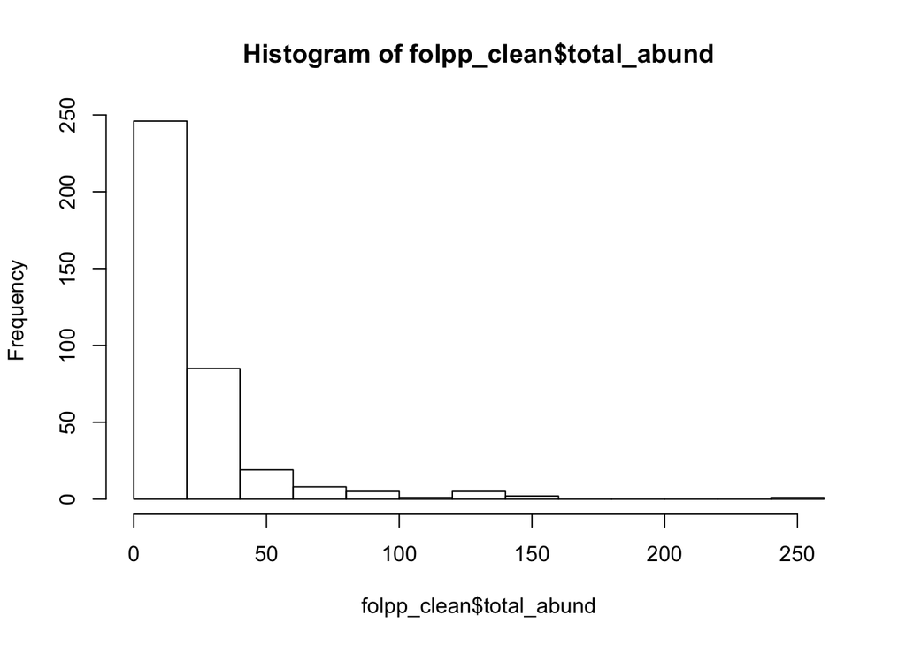

```r
############################################
#### Histogram of Total Abundance
############################################
hist(folpp_clean$total_abund)
```

```r
############################################
#### Summary Values
############################################
summary(folpp_clean$total_abund)
```

```
##    Min. 1st Qu.  Median    Mean 3rd Qu.    Max.
##    0.00    1.00   10.00   19.15   26.00  256.00
```

One option would be to use a log transformation (or log + 1 because of the excess zeroes) - this does result in a more normal distribution, as expected:

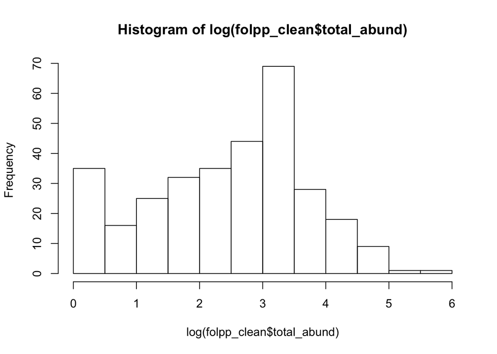

```r
############################################
### Log-transformed Abundance
############################################
hist(log(folpp_clean$total_abund))
```

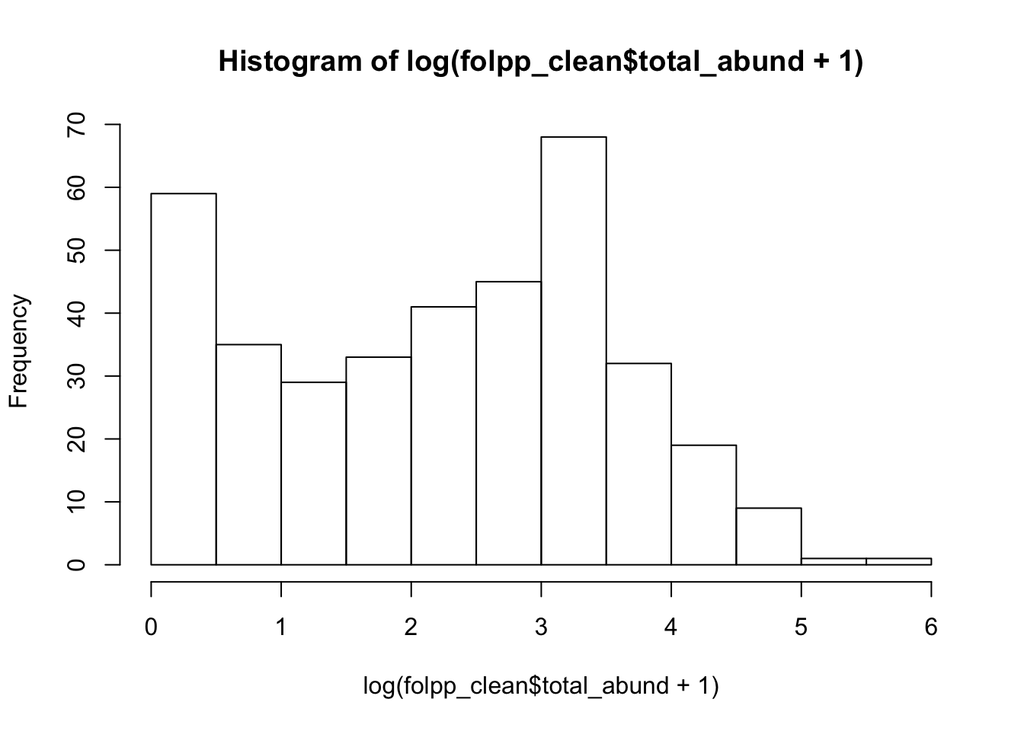

```r
############################################
### Log+1 Transformed Abundance
############################################
hist(log(folpp_clean$total_abund +1))
```

There are no missing values in the dataset:

```r
length(folpp_clean$total_abund[is.na(folpp_clean$total_abund)])
```

```
## [1] 0
```

The sampling period is the primary independent variable - before, after one year, and after two years. The histogram indicates there was consistent sampling across the three intervals:

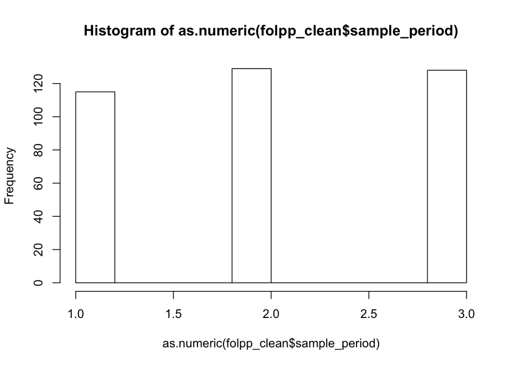

```r
hist(as.numeric(folpp_clean$sample_period))
```

The median outcome for the control group is 5 fish, and the median outcome for the impact group (for artificial reef creation) is 13 fish. This includes both before and after data:

```r
median_values <- folpp_clean %>%
  group_by(impact_control) %>%
  summarize(med_abun = median(total_abund))

median_values
```

```
## # A tibble: 2 x 2
##   impact_control med_abun
## * <chr>             <dbl>
## 1 Control               5
## 2 Impact               13
```

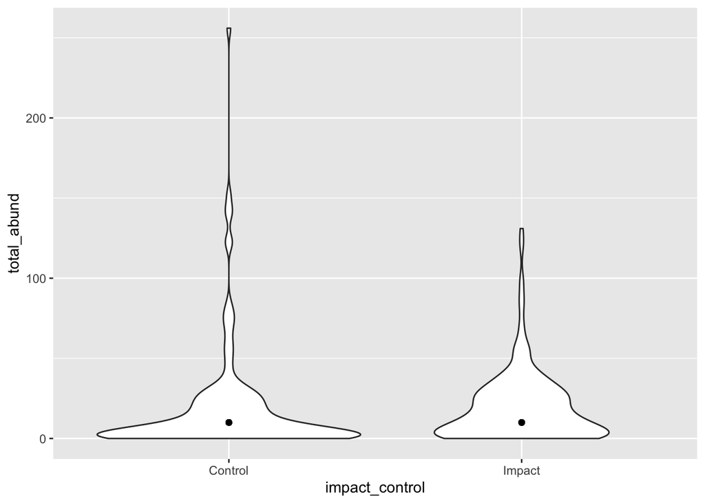

```r
#####################################################
### Violin: Just Control/Impact
#####################################################
ggplot(data = folpp_clean) +
  geom_violin(aes(x = impact_control, y = total_abund)) +
  geom_point(aes(x = impact_control, y = median(total_abund)))
```

Can also separate out the plot further to show the difference before and after:

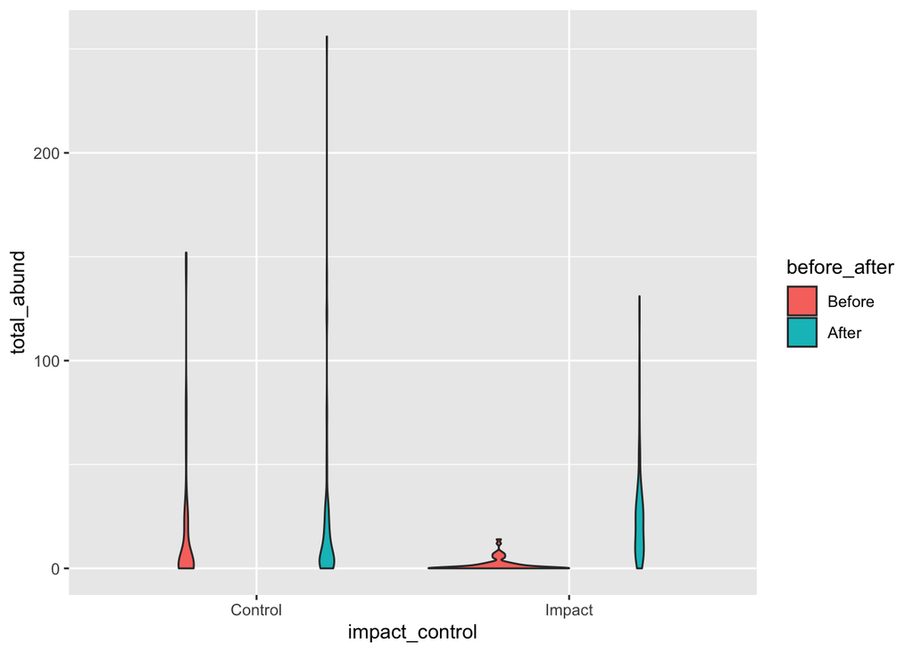

```r
#####################################################
### Violin: Control/Impact + Before/After
#####################################################
ggplot(data = folpp_clean) +
  geom_violin(aes(x = impact_control, y = total_abund,
                  fill = before_after))
```

#### First Model: glm.nb

The paper used the glmmTMB package to be able to include the random effects of sampling date and location. Since I’m less familiar with that method, I will first explore using `MASS::glm.nb` with a log link as they did in their analysis.

```r
###################################################
### Regression with MASS Package - glm.nb
###################################################
mass <- glm.nb(total_abund ~ estuary*sample_period*reef_type,
              data = folpp_clean,
              link = log)

stargazer(mass, type = "text")
```

```
##
## ====================================================================================
##                                                              Dependent variable:
##                                                          ---------------------------
##                                                                  total_abund
## ------------------------------------------------------------------------------------
## estuaryLake Macquarie                                             -0.927**
##                                                                    (0.369)
##
## estuarySt Georges Basin                                           -2.218***
##                                                                    (0.364)
##
## sample_periodAfter 1                                                0.138
##                                                                    (0.407)
##
## sample_periodAfter 2                                                0.364
##                                                                    (0.445)
##
## reef_typeAR                                                       -2.164***
##                                                                    (0.387)
##
## estuaryLake Macquarie:sample_periodAfter 1                         -0.036
##                                                                    (0.560)
##
## estuarySt Georges Basin:sample_periodAfter 1                        0.307
##                                                                    (0.553)
##
## estuaryLake Macquarie:sample_periodAfter 2                         -0.271
##                                                                    (0.588)
##
## estuarySt Georges Basin:sample_periodAfter 2                        0.115
##                                                                    (0.601)
##
## estuaryLake Macquarie:reef_typeAR                                  -0.348
##                                                                    (0.573)
##
## estuarySt Georges Basin:reef_typeAR                                -0.149
##                                                                    (0.612)
##
## sample_periodAfter 1:reef_typeAR                                  1.848***
```

[output cut: 12 more lines]

```
##                                                                    (0.796)
##
## estuarySt Georges Basin:sample_periodAfter 2:reef_typeAR           1.557*
##                                                                    (0.834)
##
## Constant                                                          3.593***
##                                                                    (0.262)
##
## ------------------------------------------------------------------------------------
## Observations                                                         372
## Log Likelihood                                                   -1,334.042
## theta                                                         0.875*** (0.071)
## Akaike Inf. Crit.                                                 2,704.084
## ====================================================================================
## Note:                                                    *p<0.1; **p<0.05; ***p<0.01
```

```r
# Use anova to compare results with those reported in the paper
Anova(mass, type = "II")
```

```
## Analysis of Deviance Table (Type II tests)
##
## Response: total_abund
##                                 LR Chisq Df Pr(>Chisq)
## estuary                           81.185  2  < 2.2e-16 ***
## sample_period                     76.437  2  < 2.2e-16 ***
## reef_type                          6.076  1   0.013706 *
## estuary:sample_period              9.033  4   0.060279 .
## estuary:reef_type                 10.319  2   0.005745 **
## sample_period:reef_type           88.996  2  < 2.2e-16 ***
## estuary:sample_period:reef_type    5.781  4   0.216077
## ---
## Signif. codes:  0 '***' 0.001 '**' 0.01 '*' 0.05 '.' 0.1 ' ' 1
```

These results are a bit different compared to what the authors got with glmmTMB, but the significance levels are somewhat similar? The strongest effects are the estuary/location, sampling period/after1-2, and the interaction between the sampling period/after 1-2 and reef type/habitat. However, the glm.nb model also showed a significant effect for the interaction between the estuary/location and the reef type/habitat.

For comparison, this is the result from the glmmTMB:

$$\begin{array}{lrcrl}
& \text{Chisq} & \text{Df} & Pr(>Chisq) & \\
\text{Location} & 22.2785 & 2 & 1.453e-05 & *** \\
\text{After.1...2} & 63.2023 & 2 & 1.887e-14 &*** \\
\text{Habitat} & 0.6020 & 1 & 0.43781 & \\
\text{Location:After.1...2} & 7.8458 & 4 & 0.09739 & . \\
\text{Location:Habitat} & 5.2276 & 2 & 0.07326 & . \\
\text{After.1...2:Habitat} & 93.4440 & 2 & < 2.2e-16 & *** \\
\text{Location:After.1...2:Habitat} & 3.2304 & 4 & 0.52004 &
\end{array}$$

##### Interpretation

For the research question, we are most interested in the interaction between sampling period and reef type to understand how the abundance of fish changed over time. Holding all other included variables constant, an artificial reef had 1.848 more fish after one year and 1.879 more fish after two years on average compared to a natural reef over the same timeframes. These results are statistically significant (p < 0.01). There were also some differential effects among the three estuaries: after one year, the artificial reefs at St. Georges Basin were associated with 1.773 more fish on average than the Botany Bay artificial reefs after the same amount of time (p < 0.05).

// PM: Interpreting the interaction terms in the regression table is tricky here because of the triple interaction. What the 1.848 coefficient is telling us is actually quite specific: it is the difference in means for just the Botany Bay group since this is the omitted category (akin to estuary = 0). So it would be: “Holding all other included variables constant, an artificial reef had 1.848 more fish after one year and 1.879 more fish after two years on average compared to a natural reef over the same timeframes in Botany Bay alone.” This is why the graphics will be so useful, because there are 18 different estimates of interest here: 6 each for Botany Bay, Lake Macquarie, and St Georges Basin. //

##### Examine Residuals

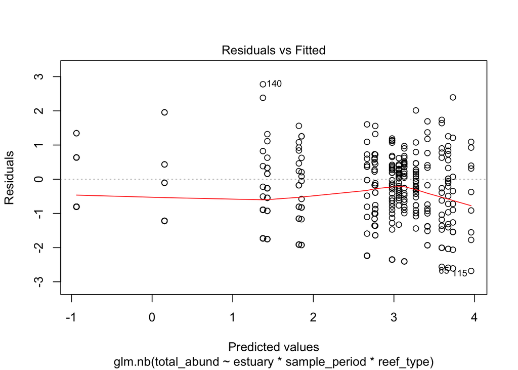

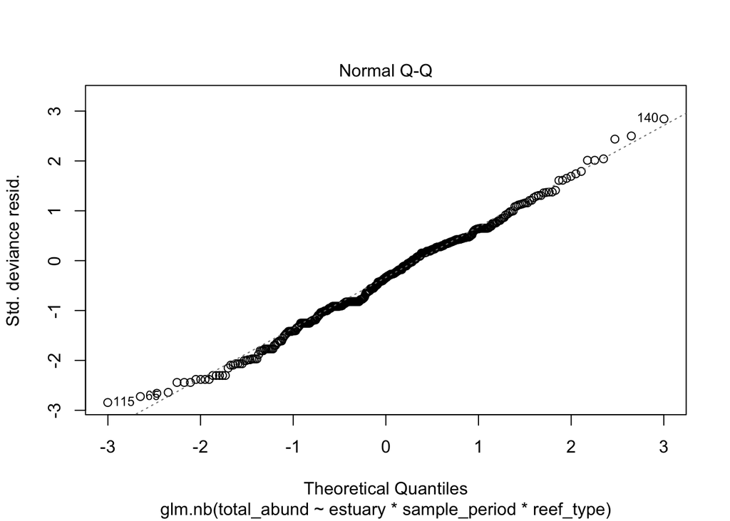

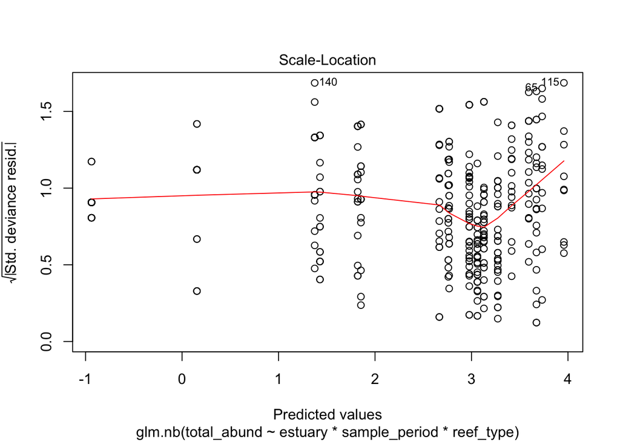

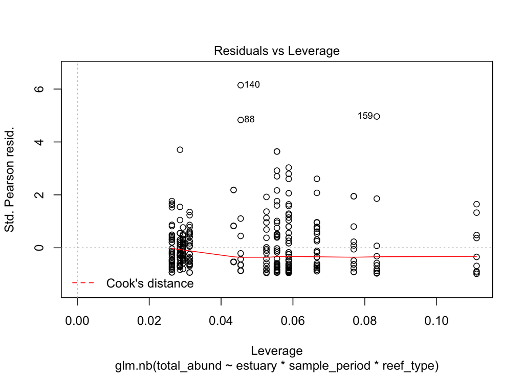

```r
plot(mass)
```

There residuals are not entirely evenly distributed, but there is not a consistent skew either - it seems like the residuals are lower in the area where the most data is distributed… which seems potentially reasonable?

PM: The residuals-vs-fitted plots are reasonable, though there is some heteroskedasticity given that there is slightly greater variance at higher predicted values than at lower predicted values (very much like the typical “funnel” shape of heteroskedastic residuals).

##### Pairwise Comparisons

```r
######################################################
## Pairwise comparisons for MASS::glm.nb
######################################################
# Using emmeans package - compare the means for each sample period (before, after 1, after 2) within
# reef type (control vs impact) within each estuary
emm_mass <- emmeans(mass,
               specs = pairwise ~ sample_period|reef_type|estuary,
               type = "response") # convert back to original scale
emm_mass$emmeans
```

```
## reef_type = NR, estuary = Botany Bay:
##  sample_period response     SE  df asymp.LCL asymp.UCL
##  Before          36.353  9.536 Inf    21.740    60.788
##  After 1         41.750 13.015 Inf    22.662    76.915
##  After 2         52.333 18.799 Inf    25.883   105.814
##
## reef_type = AR, estuary = Botany Bay:
##  sample_period response     SE  df asymp.LCL asymp.UCL
##  Before           4.176  1.191 Inf     2.389     7.303
##  After 1         30.444  7.779 Inf    18.451    50.233
##  After 2         39.368  9.759 Inf    24.218    63.997
##
## reef_type = NR, estuary = Lake Macquarie:
##  sample_period response     SE  df asymp.LCL asymp.UCL
##  Before          14.389  3.733 Inf     8.653    23.926
##  After 1         15.933  4.516 Inf     9.142    27.769
##  After 2         15.800  4.479 Inf     9.065    27.540
##
## reef_type = AR, estuary = Lake Macquarie:
##  sample_period response     SE  df asymp.LCL asymp.UCL
##  Before           1.167  0.389 Inf     0.607     2.242
##  After 1         26.371  4.842 Inf    18.401    37.795
##  After 2         21.353  3.993 Inf    14.800    30.806
##
## reef_type = NR, estuary = St Georges Basin:
##  sample_period response     SE  df asymp.LCL asymp.UCL
##  Before           3.955  0.996 Inf     2.414     6.478
##  After 1          6.176  1.711 Inf     3.589    10.629
##  After 2          6.385  2.018 Inf     3.436    11.863
##
## reef_type = AR, estuary = St Georges Basin:
##  sample_period response     SE  df asymp.LCL asymp.UCL
##  Before           0.391  0.157 Inf     0.178     0.859
##  After 1         22.844  4.398 Inf    15.664    33.315
##  After 2         19.632  3.479 Inf    13.872    27.783
##
## Confidence level used: 0.95
## Intervals are back-transformed from the log scale
```

Results shown here are somewhat different from the Table S2, suggesting that it may be good to work through using the glmmTMB instead.

#### Second Model: glmmTMB

```r
######################################################
## Using glmmTMB::glmmTMB
######################################################
tmb <- glmmTMB(total_abund ~ estuary*sample_period*reef_type + (1|site) + (1|time),
               family = nbinom2,
               data = folpp_clean)

######################################################
## Pairwise comparisons for glmmTMB
######################################################
emm_tmb <- emmeans(tmb,
                   specs = pairwise ~ sample_period|reef_type|estuary,
                   type = "response") # convert back to original scale
emm_tmb$emmeans
```

```
## reef_type = NR, estuary = Botany Bay:
##  sample_period response     SE  df lower.CL upper.CL
##  Before           32.38 11.878 351   15.740   66.621
##  After 1          24.89 10.920 351   10.505   58.989
##  After 2          44.12 19.478 351   18.515  105.131
##
## reef_type = AR, estuary = Botany Bay:
##  sample_period response     SE  df lower.CL upper.CL
##  Before            3.15  1.207 351    1.487    6.694
##  After 1          22.59  7.918 351   11.336   45.010
##  After 2          35.54 11.952 351   18.346   68.861
##
## reef_type = NR, estuary = Lake Macquarie:
##  sample_period response     SE  df lower.CL upper.CL
##  Before           13.06  4.698 351    6.434   26.493
##  After 1          14.63  5.475 351    7.007   30.539
##  After 2          14.24  5.370 351    6.786   29.896
##
## reef_type = AR, estuary = Lake Macquarie:
##  sample_period response     SE  df lower.CL upper.CL
##  Before            1.10  0.448 351    0.495    2.452
##  After 1          25.95  7.060 351   15.193   44.307
##  After 2          22.59  6.185 351   13.187   38.708
##
## reef_type = NR, estuary = St Georges Basin:
##  sample_period response     SE  df lower.CL upper.CL
##  Before            3.13  1.146 351    1.522    6.432
##  After 1           5.12  1.921 351    2.444   10.706
##  After 2           4.99  1.994 351    2.276   10.952
##
## reef_type = AR, estuary = St Georges Basin:
##  sample_period response     SE  df lower.CL upper.CL
##  Before            0.36  0.163 351    0.148    0.879
##  After 1          22.47  6.223 351   13.034   38.739
##  After 2          17.66  4.669 351   10.503   29.709
##
## Confidence level used: 0.95
## Intervals are back-transformed from the log scale
```

#### Answers for PSET 5:

2. Are there any aspects of the model you are replicating that seem problematic to you, based on the concerns we’ve covered so far in class? Do the authors attempt to address any of these concerns?

The authors do not spend much time addressing the model in the paper. There is not anything that seems immediately problematic from looking through what I have done so far. I am still working through understanding what is happening mathematically when using these types of models.

3. What are your current ideas on the extension component of the project? Are you aiming to solve some of the problems identified in question 2(b) above, and if so, how do you hope to proceed? Alternatively, if you are planning to address a question that’s not covered in the paper you are replicating, you can use this space to describe your current plans and thoughts on how you aim to proceed.

I am considering looking in more detail at comparing the two models to try to understand what is accomplished by including sampling site and date as random effects, and why that was necessary when it seems like the results were decently similar without those additional changes.